# daph

## Getting the DAPH episode

The code below is adapted from [Pawel Kapuscinski’s](http://rpubs.com/aliendeg/daph) brilliant exploration of the Digital Analytics Power Hour podcast transcripts.

```r
library(rvest)
library(dplyr)
library(stringr)
library(tidytext)
library(ggplot2)
library(ggthemes)
library(tm)
library(tidyr)
library(wordcloud)
library(tm)
library(knitr)
library(tidyverse)
library(forcats)
library(lubridate)

# Get the highest page count from the site
max_pages <- read_html("http://www.analyticshour.io/all-podcast-episodes/") %>%
  html_nodes("a.page-numbers") %>%
  html_text() %>%
  as.numeric() %>%
  max(na.rm = TRUE)

page_nums <- as.list(1:max_pages)

# Function to get a list of all archive urls along with the episode number and year
get_url_list <- function(page_num) {
  x <- read_html(paste0("http://www.analyticshour.io/all-podcast-episodes/page/", page_num))

  # Make a DF containing the url, year and episode number
  urls <- data.frame( urls = x %>%
    html_nodes(paste0("body > div.super-container.light-icons > div.main-content.page.archive-page > div > div > div > div  div > footer > ul > li.title.not-truncate ")) %>%
    html_children %>%
    as.character() %>%
    str_extract('\\\".*?\\\"') %>%
    str_replace_all(c('\"' = ''))) %>%
    separate(urls,
             into = c("bin", "bin2", "bin3", "year", "bin4", "bin5", "episode"),
             sep = "\\/",
             remove = FALSE) %>%
    mutate(urls = as.character(urls), episode = str_replace_all(episode, "\\-.*", "")) %>%
    select(urls, year, episode)

    urls
}

# Pull the urls list from the site. Ignore the "Too many values" error, this comes from the call to separate()
full_urls <- map_df(page_nums, get_url_list)

# Split the url DF into a list so it can be called by map_df below
full_urls_split <- full_urls %>%
  split(.$episode)

# Function to scrape the web content per url, append the episode #, year and speaker name (where known) then tokenize into words
get_post_content <- function(ep_df) {
  # Quick line for debugging purposes
  # print(paste("Running for :", ep_df$url))
  url <- ep_df$url
  episode <- ep_df$episode
  year <- ep_df$year

  post_html <- read_html(url)

  post_ps <- post_html %>%
    html_nodes(".post p") %>%
    html_text() %>%
    as.data.frame()

  post_title <- post_html %>%
    html_nodes(".entry-title") %>%
    html_text() %>%
    as.character()

  names(post_ps) <- "text"

  post_ps <- post_ps %>%
    dplyr::filter(str_detect(text, "(\\d{2}:)"))

  if (length(post_ps$text != 0)) {
    post_ps <- post_ps %>%
      mutate(
        text = as.character(text),
        speaker = case_when(
          str_detect(text, "(MH:)|(Michael Helbling:)|(Michael:)") ~ "Drunk Helbs",
          str_detect(text, "(MK:)|(Moe Kiss:)|(Moe:)") ~ "Moe from down under",
          str_detect(text, "(TW:)|(Tim Wilson:)|(Tim:)") ~ "Grumpy Cat",
          TRUE ~ "Unknown"
        ),
      url = url,
      episode = as.numeric(episode),
      year = year,
      title = post_title,
      time_start = as.numeric(ms(str_extract(text, "\\d{2}:\\d{2}"))),
      time_end = lead(time_start, 1),
      duration = time_end - time_start
    )
    post_ps
  } else {
    NULL
  }
}

daph_post_text <- map_df(full_urls_split, get_post_content)
saveRDS(daph_post_text, "datafiles/daph_post_text.rds")
```

# Longest monologue

Off the bat, we can find out the longest sentence of all time, and who spoke it.

```r
monologue <- daph_post_text %>%
  arrange(desc(duration)) %>%
  top_n(10, duration) %>%
  select(speaker, text, title, duration)

monologue
```

```
##        speaker
## 1   Grumpy Cat
## 2      Unknown
## 3   Grumpy Cat
## 4      Unknown
## 5      Unknown
## 6  Drunk Helbs
## 7  Drunk Helbs
## 8      Unknown
## 9  Drunk Helbs
## 10 Drunk Helbs
## 11     Unknown
## 12     Unknown
## 13     Unknown
## 14  Grumpy Cat
```

[output cut: 45 more lines]

```r
monologue$text[1]
```

```
## [1] "18:42 TW: Or if Ive even very carefully designed it, sure. If I sent 10 variations and mixed it all up, maybe that would work. I guess Im back to, it feels like its easier to understand and maybe this is cause, Matt, Ive seen enough of the Conductrics stuff and how it works and it makes tota…
```

## Tokenize our words

At this point we can split the dataframe out by words, to allow us to run sentiment analysis and word counts for the charts to follow.

```r
data("stop_words")
daph_post_words <- daph_post_text %>%
      unnest_tokens(output = word, input = text, format = "text") %>%
  anti_join(stop_words) %>%
  filter(!str_detect(word, "\\d{2}"))
saveRDS(daph_post_words, "datafiles/daph_post_words.rds")
```

## Profanity by presenter

To settle the debate for good, which presenter is the most sweary by episode?

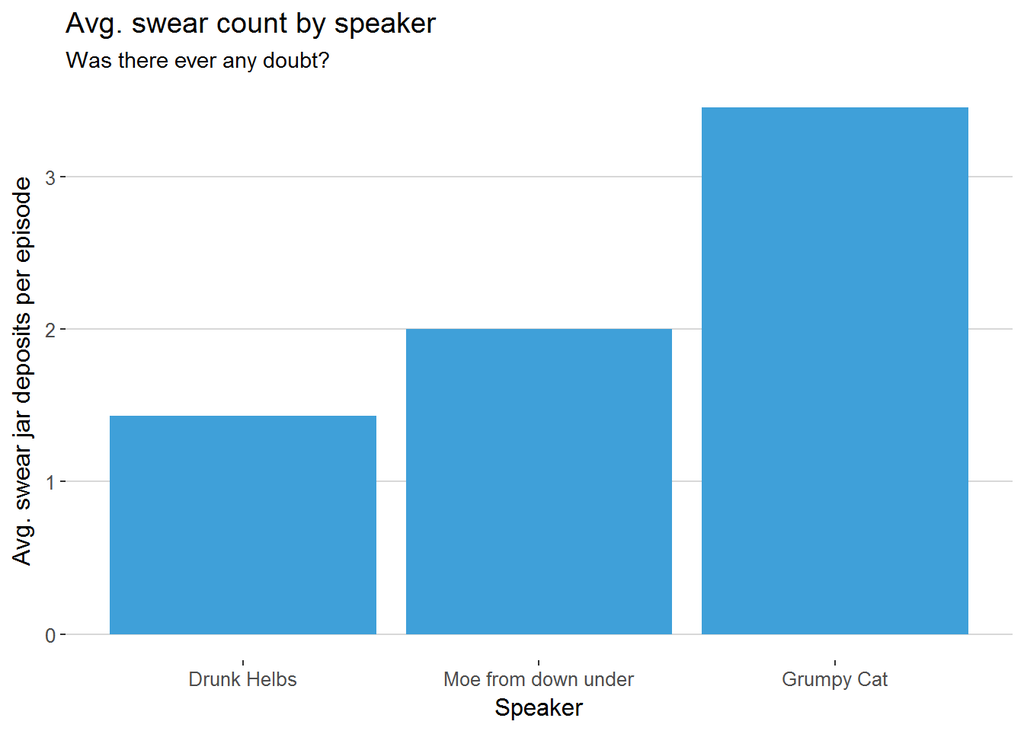

```r
swears <- daph_post_words %>%
  filter(str_detect(word, "(shit)|(fuck)|(crap)"))

swears_by_speaker <- swears %>%
  group_by(episode, speaker) %>%
  filter(speaker!= "Unknown") %>%
  summarise(ep_count = n()) %>%
  ungroup() %>%
  group_by(speaker) %>%
  summarise(avg_swears = mean(ep_count, na.rm = TRUE)) %>%
  mutate(speaker = fct_reorder(speaker, avg_swears))

swears_by_speaker %>%
  ggplot(aes(x = speaker, y = avg_swears)) +
  geom_col(fill = "#3FA0D9") +
  theme_hc() +
  labs(
    x = "Speaker",
    y = "Avg. swear jar deposits per episode",
    title = "Avg. swear count by speaker",
    subtitle = "Was there ever any doubt?")
```

# Most talkative presenter

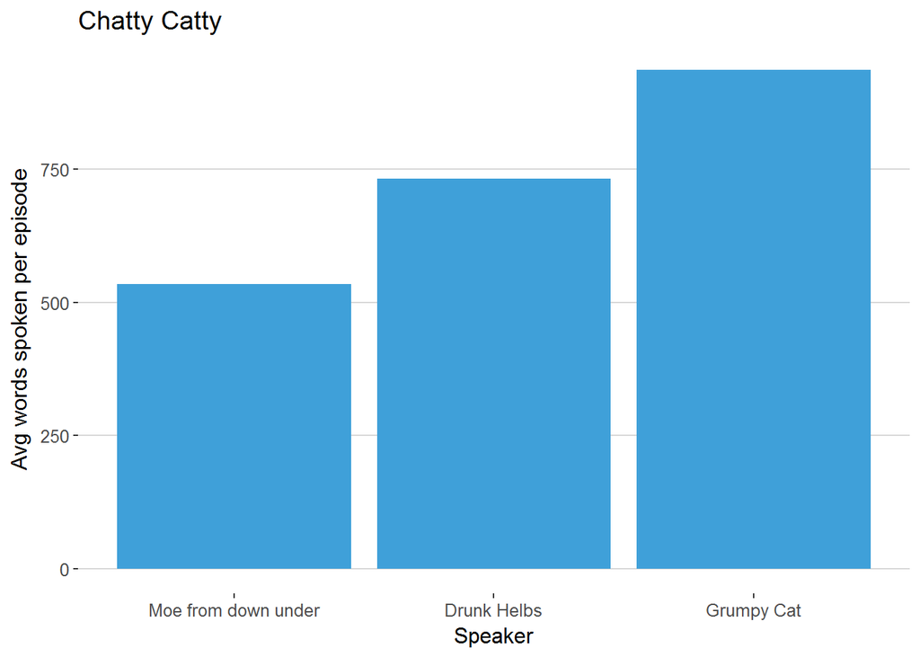

```r
# word count per episode by presenter


words_by_speaker <- daph_post_words %>%
  group_by(episode, speaker) %>%
  filter(speaker!= "Unknown") %>%
  summarise(ep_count = n()) %>%
  ungroup()

wbs_overall <- words_by_speaker %>%
  group_by(speaker) %>%
  summarise(avg_words = mean(ep_count, na.rm = TRUE)) %>%
  mutate(speaker = fct_reorder(speaker, avg_words))

wbs_overall %>%
  ggplot(aes(x = speaker, y = avg_words)) +
  geom_col(fill = "#3FA0D9") +
  theme_hc() +
  xlab('Speaker') +
  ylab('Avg words spoken per episode') +
  ggtitle("Chatty Catty")
```

```r
wbs_be <- words_by_speaker %>%
  filter(ep_count!=0) %>%
  ggplot(aes(as.numeric(episode), ep_count, colour = speaker)) +
  geom_line(na.rm = TRUE) +
  geom_point() +
  labs(
    title = "Words spoken by episode, by speaker",
    y = "Words spoken",
    x = "Episode number",
    colour = "Speaker Name"
  )
library(plotly)
ggplotly(wbs_be)
```

[interactive chart not shown]

# Episode sentiments

```r
daph_sentiment <- daph_post_words %>%
  inner_join(get_sentiments("bing"))

sentiment_by_episode <- daph_sentiment %>%
  count(episode, sentiment) %>%
  spread(sentiment, n, fill = 0) %>%
  mutate(sentiment = positive - negative)

senti_plot <- sentiment_by_episode %>%
  filter(episode > 50) %>%
  ggplot(aes(episode, sentiment)) +
  geom_col()

ggplotly(senti_plot)
```

[interactive chart not shown]

Generally, the DAPH team are an optimistic, tree-hugging bunch of people. What happened for episode 69 (“The Biases of the Analyst”), though?

Let’s take a look at which words caused all that negative skew.

```r
daph_sentiment %>%
  filter(episode == 69) %>%
  group_by(word, sentiment) %>%
  count() %>%
  arrange(sentiment, desc(n))
```

```
## # A tibble: 155 x 3
## # Groups: word, sentiment [155]
##    word     sentiment     n
##    <chr>    <chr>     <int>
##  1 bias     negative     51
##  2 biases   negative     15
##  3 hard     negative      7
##  4 wrong    negative      7
##  5 disprove negative      6
##  6 biased   negative      5
##  7 bad      negative      4
##  8 cloud    negative      4
##  9 shit     negative      4
## 10 blah     negative      3
## # ... with 145 more rows
```

Turns out “bias” and “biases” are seen as negative words according to the bing sentiment dictionary. If we remove those two words, does it change the outlook?

```r
daph_sentiment %>%
  filter(episode == 69, !str_detect(word, "bias")) %>%
  group_by(sentiment) %>%
  count()
```

```
## # A tibble: 2 x 2
## # Groups: sentiment [2]
##   sentiment     n
##   <chr>     <int>
## 1 negative    128
## 2 positive    108
```

A bit, but it’s still a negative episode overall. Words like “hard”, “wrong”, “disprove” and “shit” all contribute to a negative score overall. So, a happy analyst is an unbiased analyst.

# Happiest episode

Let’s cheer ourselves up a bit - what about the happiest episode? That was # 57 (see our plot above).

```r
daph_sentiment %>%
  filter(episode == 57) %>%
  group_by(word, sentiment) %>%
  count() %>%
  arrange(desc(sentiment), desc(n))
```

```
## # A tibble: 169 x 3
## # Groups: word, sentiment [169]
##    word       sentiment     n
##    <chr>      <chr>     <int>
##  1 amazing    positive     13
##  2 cool       positive     13
##  3 love       positive     11
##  4 pretty     positive     11
##  5 easy       positive     10
##  6 benefit    positive      9
##  7 easier     positive      8
##  8 incredible positive      7
##  9 lucky      positive      5
## 10 neat       positive      5
## # ... with 159 more rows
```

The language used here is largely descriptive, so we can’t deduce too much. However, the subject matter of the episode overall is pretty interesting - that episode was “Open Data with Brett Hurt and Jon Loyens”. So we might suggest that Open Data inspired the most excitement and positivity from the podcast team.